# SI 618: Data Manipulation and Analysis

## 01 - Introduction

### Dr. Chris Teplovs, School of Information, University of Michigan

This work is licensed under a [Creative Commons Attribution-NonCommercial-ShareAlike 4.0 International License](http://creativecommons.org/licenses/by-nc-sa/4.0/).

## What's wrong with Jupyter notebooks?

- not great for software engineering (see Joel Grus' ["I don't like notebooks"](https://docs.google.com/presentation/d/1n2RlMdmv1p25Xy5thJUhkKGvjtV-dkAIsUXP-AL4ffI/edit#slide=id.g362da58057_0_1) presentation)

```python
from IPython.display import YouTubeVideo
# a talk by Joel Grus on why he doesn't like notebooks
YouTubeVideo('7jiPeIFXb6U')
```

[video not shown]

### IMPORTANT: Replace `?` in the following code with your uniqname.

```python
MY_UNIQNAME = 'elenore'
```

Let's answer a couple of questions about the course:

### Q1: (2 points) What are you looking forward to learning in this class?

Data analysis for big data sets from all kinds of sources, and prepared for future SI 671 and job applications.

### Q2: (2 points) What are you most concerned about in this class?

So far all GSI office hours are conflicting with my class schedule, and I don't know if I can get sufficient support when I have questions. I don't like post on slack and prefer in person instructions.

### Q3: (4 points) Setup confirmation

Answer the following by editing this markdown block:

- Do you have access to the [Canvas](https://umich.instructure.com/courses/373610) site? Yes
- Do you have access to the [Slack](https://si618wn2020.slack.com) site? Yes
- Have you installed Jupyter ([Anaconda](https://www.anaconda.com))? What version of Python are you using? What version of Jupyter lab are you using? Yes, python 3.7,Jupyter lab 1.1.4

First, let's load the pandas library (which we'll cover in more detail next time):

```python
import pandas as pd
```

Execute the next block . You will see what the DataFrame looks like. It includes the number of births for each name/gender combination for each year. "df_" means DataFrame.

```python
df_names = pd.read_csv('data/names.csv')
```

```python
df_names.head()
```

|  | name | gender | birth_count | year |
| --- | --- | --- | --- | --- |
| 0 | Simeon | M | 23 | 1880 |
| 1 | Raoul | M | 7 | 1880 |
| 2 | Lou | M | 14 | 1880 |
| 3 | Myra | F | 83 | 1880 |
| 4 | Alois | M | 10 | 1880 |

We want to visualize the number of births of a specific baby name (e.g., "Mike") across the years. First, execute the following code to select birth records just for male babies named "Mike".

```python
df_mike = df_names[(df_names.name == 'Mike') & (df_names.gender == 'M')]
```

```python
df_mike.head(10)
```

|  | name | gender | birth_count | year |
| --- | --- | --- | --- | --- |
| 159 | Mike | M | 95 | 1880 |
| 2741 | Mike | M | 44 | 1881 |
| 5448 | Mike | M | 89 | 1882 |
| 7883 | Mike | M | 73 | 1883 |
| 9709 | Mike | M | 84 | 1884 |
| 11929 | Mike | M | 84 | 1885 |
| 13803 | Mike | M | 84 | 1886 |
| 16671 | Mike | M | 73 | 1887 |
| 18652 | Mike | M | 81 | 1888 |
| 22588 | Mike | M | 72 | 1889 |

To create a plot, execute the following code. The first line starting with "%" is a command that enables inline plotting for the matplotlib library in Jupyter Notebook. This line needs to be executed only once per session.

```python
import matplotlib.pyplot as plt
plt.ioff() # to prevent plots from overwriting each other
%matplotlib inline
```

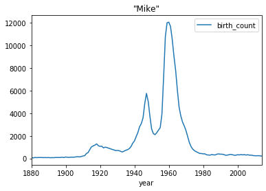

```python
df_mike.plot('year', 'birth_count', title='"Mike"')
```

### Q4: (12 points)

Repeat the above steps to create a plot for another name of your choice. Pay attention to selecting an appropriate gender ("M" or "F").

```python
df_elenore = df_names[(df_names.name == 'Elenore') & (df_names.gender == 'F')]
df_elenore.head()
```

|  | name | gender | birth_count | year |
| --- | --- | --- | --- | --- |
| 16425 | Elenore | F | 5 | 1887 |
| 19861 | Elenore | F | 6 | 1888 |
| 26688 | Elenore | F | 6 | 1891 |
| 28876 | Elenore | F | 6 | 1892 |
| 35611 | Elenore | F | 6 | 1894 |

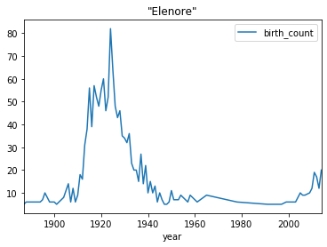

```python
df_elenore.plot('year', 'birth_count', title='"Elenore"')
```

I have such an old school name.

### Q5: (16 points)

Complete the implementation of the function below. Use the function to make plots for as many names as you like but create at least three. Then, identify at least three interesting names and explain, using complete sentences, why they're interesting.

````python
def plot_trend(name, gender):
    # TODO: complete your function here
    #       so that it creates a plot for the specified name and gender.
    #       e.g., plot_trend("Mike", "M") should generate the same plot as above.
    #       You will need to replace the ```pass``` statment in the following line
    df_name = df_names[(df_names.name == name) & (df_names.gender == gender)]
    df_name.plot('year', 'birth_count', title=name)
````

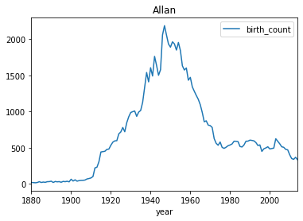

```python
# call the above function with different names and genders
plot_trend('Allan','M')
```

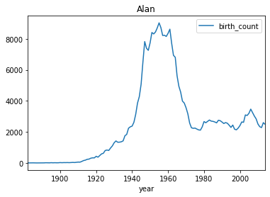

```python
plot_trend('Alan','M')
```

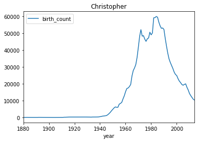

```python
plot_trend('Christopher','M')
```

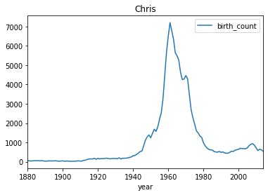

```python
plot_trend('Chris','M')
```

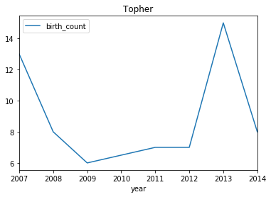

```python
plot_trend('Topher','M')
```

# END OF NOTEBOOK

## Remember to submit this file in IPYNB and HTML format via Canvas.

# Preparing for next class

See Syllabus

1. Review python basics: McKinney Chapters 1, 2, and 3
2. Study McKinney Chapters 4, 5, and 6, plus "Data Wrangling with Python & Pandas"